# Project 2 - Data Clusterring - Introduction to Machine Learning

### Maja Andrzejczuk & Julia Przybytniowska

```python
import pandas as pd
import numpy as np
import matplotlib.pyplot as plt
import seaborn as sns

from nltk.tokenize import word_tokenize
from nltk.stem.snowball import SnowballStemmer
from nltk.stem import PorterStemmer, WordNetLemmatizer
from nltk.corpus import stopwords

import warnings
warnings.filterwarnings('ignore')
```

## Contents

- **1.Creating Dataset**
- **2.EDA**
- **3.Feature engineering**
- **4.Clustering**
- **5.Best model interpretability**

## Creating Dataset

```python
#join for each publisher files vocab i docword
files = pd.DataFrame([["data/docword.enron.csv","data/vocab.enron.txt"],
         ["data/docword.kos.csv","data/vocab.kos.txt"],
         ["data/docword.nips.csv","data/vocab.nips.txt"],
         ["data/docword.nytimes.csv", "data/vocab.nytimes.txt"]])
names = ["data/enron.csv", 'data/kos.csv', "data/nips.csv", "data/nytimes.csv"]
publishers = ["enron", "kos", "nips", "nytimes"]

for i in range(4):
    if i != 0:
        doc = pd.read_csv(files[0][i], skiprows = 4, index_col=None, header=None, names=['docId', 'wordId', 'count'], delimiter = ";")
    else:
        doc = pd.read_csv(files[0][i], skiprows = 4, index_col=None, header=None, names=['docId', 'wordId', 'count'])
    doc = doc.groupby(['wordId', "docId"])['count'].sum().reset_index()
    voc = pd.read_csv(files[1][i], index_col=None, header=None, names=['word'])
    voc['wordId'] = range(1, len(voc) + 1)
    pub = voc.merge(doc, on = 'wordId')
    pub = pub.drop(columns = ['wordId'])
    pub.columns = ["word","docId", "count"]
    pub["publisher"] = publishers[i]
    pub.to_csv(names[i], index = False)
```

Let's have a look how it looks for one publisher:

```python
pd.read_csv(names[1], index_col = None)
```

|  | word | docId | count | publisher |
| --- | --- | --- | --- | --- |
| 0 | aarp | 1441 | 3 | kos |
| 1 | aarp | 2329 | 1 | kos |
| 2 | aarp | 2330 | 8 | kos |
| 3 | abandon | 183 | 1 | kos |
| 4 | abandon | 374 | 1 | kos |
| ... | ... | ... | ... | ... |
| 353154 | zones | 2321 | 1 | kos |
| 353155 | zones | 2873 | 1 | kos |
| 353156 | zones | 3056 | 1 | kos |
| 353157 | zones | 3337 | 1 | kos |
| 353158 | zones | 3414 | 1 | kos |

353159 rows × 4 columns

```python
# merge all publishers
data = pd.read_csv(names[0], index_col = None)
for i in range(3):
    data2 = pd.read_csv(names[i+1], index_col = None)
    maxId = max(data["docId"])
    data2["docId"] = data2["docId"] + maxId
    data = pd.concat([data, data2])
```

Our full dataset which we will use for further analysis:

```python
data
```

|  | word | docId | count | publisher |
| --- | --- | --- | --- | --- |
| 0 | aaa | 1684 | 1.0 | enron |
| 1 | aaa | 2093 | 1.0 | enron |
| 2 | aaa | 2182 | 1.0 | enron |
| 3 | aaa | 2281 | 1.0 | enron |
| 4 | aaa | 2609 | 1.0 | enron |
| ... | ... | ... | ... | ... |
| 1048567 | zzz_zurich | 47219 | 1.0 | nytimes |
| 1048568 | zzz_zurich | 47266 | 1.0 | nytimes |
| 1048569 | zzz_zurich | 49550 | 1.0 | nytimes |
| 1048570 | zzz_zvi_griliches | 46774 | 1.0 | nytimes |
| 1048571 | zzz_zydrunas_ilgauskas | 44866 | 4.0 | nytimes |

5858466 rows × 4 columns

```python
data.to_csv("data/prepared_data_with_docID.csv")
```

## EDA

For now we will analyse just words (without grouping them on publisher or document):

```python
df = pd.read_csv("data/prepared_data.csv", index_col = 0)
```

```python
df.sort_values('sum', ascending=False).head(10)
```

|  | word | count_1 | count_2 | count_3 | count_4 | sum |
| --- | --- | --- | --- | --- | --- | --- |
| 19186 | power | 32985.0 | 305.0 | 1072.0 | 1290.0 | 35652.0 |
| 4864 | company | 32115.0 | 126.0 | 49.0 | 3279.0 | 35569.0 |
| 16836 | network | 5247.0 | 137.0 | 25977.0 | 828.0 | 32189.0 |
| 8241 | energy | 28024.0 | 183.0 | 1378.0 | 247.0 | 29832.0 |
| 15228 | market | 24910.0 | 92.0 | 140.0 | 1952.0 | 27094.0 |
| 3449 | california | 24456.0 | 174.0 | 461.0 | 10.0 | 25101.0 |
| 16147 | model | 2015.0 | 60.0 | 18665.0 | 432.0 | 21172.0 |
| 17288 | number | 10574.0 | 403.0 | 7614.0 | 1724.0 | 20315.0 |
| 22543 | set | 6521.0 | 256.0 | 11677.0 | 1691.0 | 20145.0 |
| 3283 | business | 16963.0 | 156.0 | 23.0 | 1885.0 | 19027.0 |

The most commonly used word is *power*.

We will see what the distribution of the number of words' repetitions is (whether many are repeated many times or more singly):

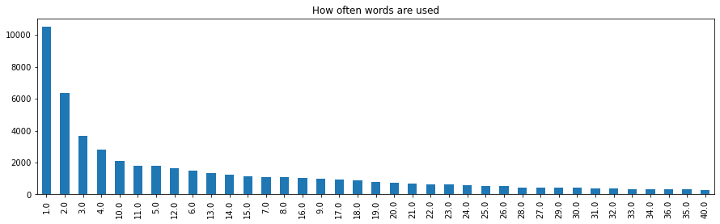

```python
f = plt.figure()
f.set_figwidth(15)
df["sum"].value_counts()[:40].plot(kind='bar', title = 'How often words are used')
```

Unfortunately, mostly words are used once or twice. Probably after further analysis and data engineering some of these will be removed.

Next important thing to see is what word's length is most common:

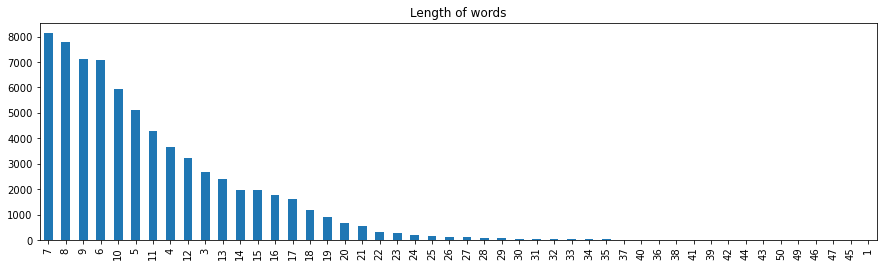

```python
df['count_letters'] = df['word'].str.len()
f = plt.figure()
f.set_figwidth(15)
df['count_letters'].value_counts().plot(kind = 'bar', title = "Length of words")
```

Most words are of length 6, 7, 8 and 9, so it does not look any suspicious. Surprisingly, our dataset contains also words of length 50, which may be puzzling.

Next we checked whether our collection contains mostly positive, negative or neutral words. Unfortunately we do not have any surprising conclusions.

```python
import nltk
from nltk.sentiment.vader import SentimentIntensityAnalyzer
from nltk.corpus import twitter_samples
from collections import Counter

nltk.download('twitter_samples')
nltk.download('vader_lexicon')

# select the set of positive and negative tweets
all_positive_tweets = twitter_samples.strings('positive_tweets.json')
all_negative_tweets = twitter_samples.strings('negative_tweets.json')

analyzer = SentimentIntensityAnalyzer()
```

```python
a = list(df['word'])
# converting list into string and then joining it with space
b = ' '.join(str(e) for e in a)
```

```python
score_array = analyzer.polarity_scores(b)
```

```python
pd.DataFrame.from_dict(score_array, orient='index').drop('compound')
```

|  | 0 |
| --- | --- |
| neg | 0.071 |
| neu | 0.874 |
| pos | 0.055 |

Neutral words represent 87% of our base , 7% negative, and less than 6% positive

We considered worthy to also check what parts of speech are most common in our database:

```python
nltk.download('averaged_perceptron_tagger')
nltk.download('tagsets')
nltk.download('punkt')
nltk.download('omw-1.4')
```

```
True
```

```python
a = list(df['word'])
b = ' '.join(str(e) for e in a)

words_in_sagan_quote = word_tokenize(b)
nltk.pos_tag(words_in_sagan_quote)
```

[output not shown]

[output cut: 946 more lines]

[output not shown]

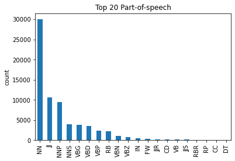

```python
from textblob import TextBlob
import cufflinks as cf

cf.go_offline()
cf.set_config_file(offline=False, world_readable=True)

blob = TextBlob(str(b))
pos_df = pd.DataFrame(blob.tags, columns = ['word' , 'pos'])
pos_df = pos_df.pos.value_counts()[:20]

pos_df.plot(kind="bar", title = "Top 20 Part-of-speech", ylabel="count")
plt.show()
```

The most common parts of speech in our database are nouns. Adjectives are the second most popular group.

## Feature engineering

```python
data = pd.read_csv("data/prepared_data_with_docID.csv", index_col = 0)
```

Our next step is checking if we have numerical values in our set (if there are any we will remove them).

```python
data = data[~data['word'].str.isnumeric().isna()]
data
```

|  | word | docId | count | publisher |
| --- | --- | --- | --- | --- |
| 0 | aaa | 1684 | 1.0 | enron |
| 1 | aaa | 2093 | 1.0 | enron |
| 2 | aaa | 2182 | 1.0 | enron |
| 3 | aaa | 2281 | 1.0 | enron |
| 4 | aaa | 2609 | 1.0 | enron |
| ... | ... | ... | ... | ... |
| 1048567 | zzz_zurich | 47219 | 1.0 | nytimes |
| 1048568 | zzz_zurich | 47266 | 1.0 | nytimes |
| 1048569 | zzz_zurich | 49550 | 1.0 | nytimes |
| 1048570 | zzz_zvi_griliches | 46774 | 1.0 | nytimes |
| 1048571 | zzz_zydrunas_ilgauskas | 44866 | 4.0 | nytimes |

5858383 rows × 4 columns

We will then reduce all words to their subject so that the same words in a different variety count as one. In order of that we will use two functions:

- stemming
- lammatization

```python
def stemming(text):
    nltk_stemmList = []
    for word in text:
        nltk_stemmList.append(PorterStemmer().stem(word))
    return nltk_stemmList
```

```python
def lemmatization(text):
    nltk_lemmaList = []
    for word in text:
        nltk_lemmaList.append(WordNetLemmatizer().lemmatize(word))
    return nltk_lemmaList
```

```python
stemming_lemma_list = lemmatization(stemming(df['word'].values))
lemma_list = lemmatization(df['word'].values)
stemming_list = stemming(df['word'].values)
lemma_stemming_list = stemming(lemmatization(df['word'].values))


print(f"Origin list of words contains {len(df['word'].values)} unique values")

stemming_list_unique = list(set(stemming_list))
print(f"List after stemming contains: {len(stemming_list_unique)} unique values")

lemma_list_unique = list(set(lemma_list))
print(f"List after lemmatyzation contains {len(lemma_list_unique)} unique values")

stemming_lemma_list_unique = list(set(stemming_lemma_list))
print(f"List after stemming + lemmatyzation contains {len(stemming_lemma_list_unique)} unique values")

lemma_stemming_list_unique = list(set(lemma_stemming_list))
print(f"List after lemmatization + stemming contains {len(lemma_stemming_list_unique)} unique values")
```

```
Origin list of words contains 69771 unique values
List after stemming contains: 54185 unique values
List after lemmatyzation contains 66706 unique values
List after stemming + lemmatyzation contains 54080 unique values
List after lemmatization + stemming contains 54078 unique values
```

The order of executing functions has slightly different result. It can be caused by the fact that lemmatization process in most cases removes the last letter, what can ruin the truth of results.

```python
data['stemmed'] = lemmatization(stemming(data['word']))
data
```

|  | word | docId | count | publisher | stemmed |
| --- | --- | --- | --- | --- | --- |
| 0 | aaa | 1684 | 1.0 | enron | aaa |
| 1 | aaa | 2093 | 1.0 | enron | aaa |
| 2 | aaa | 2182 | 1.0 | enron | aaa |
| 3 | aaa | 2281 | 1.0 | enron | aaa |
| 4 | aaa | 2609 | 1.0 | enron | aaa |
| ... | ... | ... | ... | ... | ... |
| 1048567 | zzz_zurich | 47219 | 1.0 | nytimes | zzz_zurich |
| 1048568 | zzz_zurich | 47266 | 1.0 | nytimes | zzz_zurich |
| 1048569 | zzz_zurich | 49550 | 1.0 | nytimes | zzz_zurich |
| 1048570 | zzz_zvi_griliches | 46774 | 1.0 | nytimes | zzz_zvi_grilich |
| 1048571 | zzz_zydrunas_ilgauskas | 44866 | 4.0 | nytimes | zzz_zydrunas_ilgauska |

5858383 rows × 5 columns

```python
df['stemmed'] = lemmatization(stemming(df['word']))
df = df.groupby(['stemmed']).sum().reset_index()
df
```

|  | stemmed | count_1 | count_2 | count_3 | count_4 | sum | count_letters |
| --- | --- | --- | --- | --- | --- | --- | --- |
| 0 | 0 | 27.0 | 0.0 | 141.0 | 25.0 | 193.0 | 1 |
| 1 | a2i | 0.0 | 0.0 | 8.0 | 0.0 | 8.0 | 3 |
| 2 | aa | 49.0 | 0.0 | 0.0 | 0.0 | 49.0 | 3 |
| 3 | aaa | 53.0 | 0.0 | 19.0 | 0.0 | 72.0 | 7 |
| 4 | aaai | 0.0 | 0.0 | 67.0 | 0.0 | 67.0 | 4 |
| ... | ... | ... | ... | ... | ... | ... | ... |
| 54075 | zzz_zorro | 0.0 | 0.0 | 0.0 | 1.0 | 1.0 | 9 |
| 54076 | zzz_zulu | 0.0 | 0.0 | 0.0 | 2.0 | 2.0 | 8 |
| 54077 | zzz_zurich | 0.0 | 0.0 | 0.0 | 4.0 | 4.0 | 10 |
| 54078 | zzz_zvi_grilich | 0.0 | 0.0 | 0.0 | 1.0 | 1.0 | 17 |
| 54079 | zzz_zydrunas_ilgauska | 0.0 | 0.0 | 0.0 | 4.0 | 4.0 | 22 |

54080 rows × 7 columns

```python
data = data.groupby(['stemmed', "docId", "publisher"]).sum().reset_index()
data
```

|  | stemmed | docId | publisher | count |
| --- | --- | --- | --- | --- |
| 0 | a2i | 44436 | nips | 1.0 |
| 1 | a2i | 44563 | nips | 4.0 |
| 2 | a2i | 44598 | nips | 1.0 |
| 3 | a2i | 44686 | nips | 1.0 |
| 4 | a2i | 44732 | nips | 1.0 |
| ... | ... | ... | ... | ... |
| 5406773 | zzz_zurich | 47219 | nytimes | 1.0 |
| 5406774 | zzz_zurich | 47266 | nytimes | 1.0 |
| 5406775 | zzz_zurich | 49550 | nytimes | 1.0 |
| 5406776 | zzz_zvi_grilich | 46774 | nytimes | 1.0 |
| 5406777 | zzz_zydrunas_ilgauska | 44866 | nytimes | 4.0 |

5406778 rows × 4 columns

Let's see how histogram of word's use changed after our last steps.

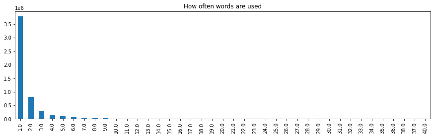

```python
f = plt.figure()
f.set_figwidth(15)
data["count"].value_counts()[:40].plot(kind='bar', title = 'How often words are used')
```

```python
df['stemmed'].loc[df['sum']==1].tail(20)
```

```
54030    zzz_zachary_taylor
54031              zzz_zack
54034              zzz_zale
54037              zzz_zane
54038            zzz_zantac
54040       zzz_zdeno_chara
54041              zzz_zdtv
54044      zzz_zefross_moss
54053         zzz_zhang_yim
54055       zzz_zhu_bangzao
54061         zzz_zinfandel
54063           zzz_zionism
54066            zzz_ziploc
54067             zzz_zippo
54068            zzz_zocalo
54069               zzz_zoe
54072             zzz_zoran
54074       zzz_zoroastrian
54075             zzz_zorro
54078       zzz_zvi_grilich
Name: stemmed, dtype: object
```

We can see that if we remove the prefix "zzz*" we will have real words and perhaps this will help us to further reduce the dataset. The same situation is with words ending in multiple "*".

```python
data['stemmed'] = data['stemmed'].str.lstrip("zzz_")
data['stemmed'] = data['stemmed'].str.rstrip("_")
data = data.groupby(['stemmed', "docId", "publisher"]).sum().reset_index()
```

And how did length of words change?

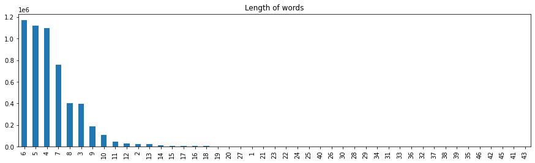

```python
data['count_letters_stemmed'] = data['stemmed'].str.len()
f = plt.figure()
f.set_figwidth(15)
data['count_letters_stemmed'].value_counts().plot(kind = 'bar', title = "Length of words")
```

```python
data['count_letters_stemmed'].value_counts()
```

```
6     1171044
5     1121389
4     1099429
7      757335
8      399232
3      396760
9      184998
10     107690
11      44893
12      28062
2       24438
13      23526
14      14031
15       6907
17       6503
```

[output cut: 31 more lines]

Then there are the extremely long words. Let's see what they are:

```python
data['stemmed'].loc[data['count_letters_stemmed']>10].tail(20)
```

```
5400664                         young_children
5400665                      young_column_waco
5400666                      young_column_waco
5400667                      young_column_waco
5400668                      young_column_waco
5400669                      young_column_waco
5400670                      young_column_waco
5400672                            young_peopl
5403473                         youth_intellig
5403474                         youth_intellig
5403475                         youth_intellig
5404381                        yoweri_museveni
5404382                        yoweri_museveni
5404643                          yugoslav_left
5404644    yugoslav_president_slobodan_milosev
5404683                            yugoslavian
5404789                          yuri_andropov
5404790                          yuri_andropov
5404813                        yves_saint_laur
5404826                         yvonne_abraham
Name: stemmed, dtype: object
```

```python
data['stemmed'].loc[data['count_letters_stemmed']>30].tail(20)
```

```
5087511    u_s_district_judge_thomas_penfield_jackson
5087512    u_s_district_judge_thomas_penfield_jackson
5087513    u_s_district_judge_thomas_penfield_jackson
5087514          u_s_district_judge_walter_s_smith_jr
5087515          u_s_district_judge_walter_s_smith_jr
5087516          u_s_district_judge_walter_s_smith_jr
5087517          u_s_district_judge_walter_s_smith_jr
5087518          u_s_district_judge_walter_s_smith_jr
5087525      u_s_equal_employment_opportunity_commiss
5087526      u_s_equal_employment_opportunity_commiss
5087527      u_s_equal_employment_opportunity_commiss
5090981               un_secretary_general_kofi_annan
5090982               un_secretary_general_kofi_annan
5119683               united_nations_security_council
5119684               united_nations_security_council
5119685               united_nations_security_council
5119686               united_nations_security_council
5302786      white_house_press_secretary_joe_lockhart
5361460             world_intellectual_property_organ
5404644           yugoslav_president_slobodan_milosev
Name: stemmed, dtype: object
```

```python
df2 = data.loc[data['count_letters_stemmed']>30].assign(stemmed=data['stemmed'].str.split('_')).explode('stemmed')
data = pd.concat([data,df2]).groupby(['stemmed', "docId", "publisher"]).sum().reset_index()

data['count_letters_stemmed'] = data['stemmed'].str.len()
data['stemmed'].loc[data['count_letters_stemmed']>30].count()
data
```

|  | stemmed | docId | publisher | count | count_letters_stemmed |
| --- | --- | --- | --- | --- | --- |
| 0 | 7_eleven | 47106 | nytimes | 1.0 | 8 |
| 1 | 7_eleven | 47733 | nytimes | 1.0 | 8 |
| 2 | 7_eleven | 48929 | nytimes | 1.0 | 8 |
| 3 | 7_eleven | 49007 | nytimes | 1.0 | 8 |
| 4 | a2i | 44436 | nips | 1.0 | 3 |
| ... | ... | ... | ... | ... | ... |
| 5406315 | yzaguirr | 37723 | enron | 1.0 | 8 |
| 5406316 | yzaguirr | 37874 | enron | 1.0 | 8 |
| 5406317 | yzaguirr | 38032 | enron | 1.0 | 8 |
| 5406318 | yzaguirr | 38087 | enron | 1.0 | 8 |
| 5406319 | yzaguirr | 38114 | enron | 1.0 | 8 |

5406320 rows × 5 columns

Next important step is removing english *stopwords*. They are probably often used by publishers, but we can't get any information from them.

```python
stops =  list(stopwords.words('english'))
data['stemmed'].isin(stops).value_counts()
print([word for word in np.unique(data['stemmed']) if word in stops])
```

```
['against', 'ain', 'an', 'and', 'are', 'aren', 'as', 'at', 'be', 'but', 'can', 'd', 'didn', 'do', 'doesn', 'don', 'down', 'each', 'from', 'further', 'hasn', 'have', 'haven', 'he', 'her', 'here', 'how', 'i', 'if', 'in', 'isn', 'it', 'm', 'ma', 'me', 'more', 'mustn', 'needn', 'no', 'not', 'now', 'o', …
```

```python
data = data[~data['stemmed'].isin(stops)]
data = data[~data['stemmed'].str.isdigit()]
data
```

|  | stemmed | docId | publisher | count | count_letters_stemmed |
| --- | --- | --- | --- | --- | --- |
| 0 | 7_eleven | 47106 | nytimes | 1.0 | 8 |
| 1 | 7_eleven | 47733 | nytimes | 1.0 | 8 |
| 2 | 7_eleven | 48929 | nytimes | 1.0 | 8 |
| 3 | 7_eleven | 49007 | nytimes | 1.0 | 8 |
| 4 | a2i | 44436 | nips | 1.0 | 3 |
| ... | ... | ... | ... | ... | ... |
| 5406315 | yzaguirr | 37723 | enron | 1.0 | 8 |
| 5406316 | yzaguirr | 37874 | enron | 1.0 | 8 |
| 5406317 | yzaguirr | 38032 | enron | 1.0 | 8 |
| 5406318 | yzaguirr | 38087 | enron | 1.0 | 8 |
| 5406319 | yzaguirr | 38114 | enron | 1.0 | 8 |

5388472 rows × 5 columns

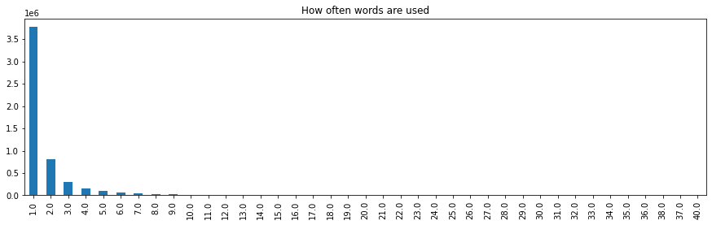

```python
f = plt.figure()
f.set_figwidth(15)
data["count"].value_counts()[:40].plot(kind='bar',  title = 'How often words are used')
```

We consider worthy removing words from the database that occure less than 10 times (in sum and in one document). We are aware it's a major constraint but otherwise our laptops weren't able to compile it.

```python
help_with_sum = data.merge(df, on="stemmed", how = "left").drop(columns = ["count_1", "count_2", "count_3", "count_4", "count_letters", "count_letters_stemmed"])
```

```python
data = help_with_sum[help_with_sum["sum"] >= 10].drop(columns = ["sum"])
data = data[data["count"] >= 10]
```

```python
data
```

|  | stemmed | docId | publisher | count |
| --- | --- | --- | --- | --- |
| 96 | aaa | 6485 | enron | 17.0 |
| 585 | aaron | 48842 | nytimes | 16.0 |
| 685 | aazhang | 43321 | nips | 13.0 |
| 740 | ab1x | 22160 | enron | 16.0 |
| 747 | ab1x | 23320 | enron | 16.0 |
| ... | ... | ... | ... | ... |
| 5388064 | ypc | 21949 | enron | 22.0 |
| 5388322 | yuill | 43781 | nips | 17.0 |
| 5388351 | yuill | 44601 | nips | 19.0 |
| 5388353 | yuill | 44616 | nips | 12.0 |
| 5388407 | yurkanin | 22321 | enron | 10.0 |

99136 rows × 4 columns

For later clustering we need to use StandardScaler() on column `count`.

```python
from sklearn.preprocessing import StandardScaler

to_normalize = ['count']
data.loc[:, to_normalize] = StandardScaler().fit_transform(data.loc[:, to_normalize])
```

```python
data
```

|  | stemmed | docId | publisher | count |
| --- | --- | --- | --- | --- |
| 96 | aaa | 6485 | enron | -0.101006 |
| 585 | aaron | 48842 | nytimes | -0.182554 |
| 685 | aazhang | 43321 | nips | -0.427198 |
| 740 | ab1x | 22160 | enron | -0.182554 |
| 747 | ab1x | 23320 | enron | -0.182554 |
| ... | ... | ... | ... | ... |
| 5388064 | ypc | 21949 | enron | 0.306733 |
| 5388322 | yuill | 43781 | nips | -0.101006 |
| 5388351 | yuill | 44601 | nips | 0.062090 |
| 5388353 | yuill | 44616 | nips | -0.508746 |
| 5388407 | yurkanin | 22321 | enron | -0.671842 |

99136 rows × 4 columns

Our final step of feature engeneering is modyfying our dataset from long to wide (with words as a columns):

```python
final=data.pivot(index=['docId', "publisher"], columns='stemmed', values='count')
```

```python
final = final.reset_index().drop(columns = ['publisher']).fillna(0)
final
```

| stemmed | docId | aaa | aaron | aazhang | ab1x | abandon | abbott | abc | abel | abi | ... | yesterday | yield | ying | ylx | yore | york | young | ypc | yuill | yurkanin |
| --- | --- | --- | --- | --- | --- | --- | --- | --- | --- | --- | --- | --- | --- | --- | --- | --- | --- | --- | --- | --- | --- |
| 0 | 24 | 0.0 | 0.0 | 0.0 | 0.0 | 0.0 | 0.0 | 0.0 | 0.0 | 0.0 | ... | 0.0 | 0.0 | 0.0 | 0.0 | 0.0 | 0.0 | 0.0 | 0.0 | 0.0 | 0.0 |
| 1 | 28 | 0.0 | 0.0 | 0.0 | 0.0 | 0.0 | 0.0 | 0.0 | 0.0 | 0.0 | ... | 0.0 | 0.0 | 0.0 | 0.0 | 0.0 | 0.0 | 0.0 | 0.0 | 0.0 | 0.0 |
| 2 | 40 | 0.0 | 0.0 | 0.0 | 0.0 | 0.0 | 0.0 | 0.0 | 0.0 | 0.0 | ... | 0.0 | 0.0 | 0.0 | 0.0 | 0.0 | 0.0 | 0.0 | 0.0 | 0.0 | 0.0 |
| 3 | 77 | 0.0 | 0.0 | 0.0 | 0.0 | 0.0 | 0.0 | 0.0 | 0.0 | 0.0 | ... | 0.0 | 0.0 | 0.0 | 0.0 | 0.0 | 0.0 | 0.0 | 0.0 | 0.0 | 0.0 |
| 4 | 86 | 0.0 | 0.0 | 0.0 | 0.0 | 0.0 | 0.0 | 0.0 | 0.0 | 0.0 | ... | 0.0 | 0.0 | 0.0 | 0.0 | 0.0 | 0.0 | 0.0 | 0.0 | 0.0 | 0.0 |
| ... | ... | ... | ... | ... | ... | ... | ... | ... | ... | ... | ... | ... | ... | ... | ... | ... | ... | ... | ... | ... | ... |
| 11564 | 49575 | 0.0 | 0.0 | 0.0 | 0.0 | 0.0 | 0.0 | 0.0 | 0.0 | 0.0 | ... | 0.0 | 0.0 | 0.0 | 0.0 | 0.0 | 0.0 | 0.0 | 0.0 | 0.0 | 0.0 |
| 11565 | 49576 | 0.0 | 0.0 | 0.0 | 0.0 | 0.0 | 0.0 | 0.0 | 0.0 | 0.0 | ... | 0.0 | 0.0 | 0.0 | 0.0 | 0.0 | 0.0 | 0.0 | 0.0 | 0.0 | 0.0 |
| 11566 | 49577 | 0.0 | 0.0 | 0.0 | 0.0 | 0.0 | 0.0 | 0.0 | 0.0 | 0.0 | ... | 0.0 | 0.0 | 0.0 | 0.0 | 0.0 | 0.0 | 0.0 | 0.0 | 0.0 | 0.0 |
| 11567 | 49578 | 0.0 | 0.0 | 0.0 | 0.0 | 0.0 | 0.0 | 0.0 | 0.0 | 0.0 | ... | 0.0 | 0.0 | 0.0 | 0.0 | 0.0 | 0.0 | 0.0 | 0.0 | 0.0 | 0.0 |
| 11568 | 49579 | 0.0 | 0.0 | 0.0 | 0.0 | 0.0 | 0.0 | 0.0 | 0.0 | 0.0 | ... | 0.0 | 0.0 | 0.0 | 0.0 | 0.0 | 0.0 | 0.0 | 0.0 | 0.0 | 0.0 |

11569 rows × 6913 columns

Above we can see that word 'yurkanin' appears (after scalling) -0.671842 times in document 22321. Let's check if we are able to read same info from our final data:

```python
help = final[final["docId"] == 22321]
help.loc[:, ~help.isin([0]).any(axis=0)]
```

| stemmed | docId | market | oper | yurkanin |
| --- | --- | --- | --- | --- |
| 3027 | 22321 | -0.264102 | -0.671842 | -0.671842 |

To have easier work on project every new created dataframe we export to .csv file, to later not be obligated to read all cells from the very beginning.

```python
final.to_csv("final.csv")
```

```python
data = pd.read_csv("final.csv", index_col = 0)
```

```python
data.head()
```

|  | docId | aaa | aaron | aazhang | ab1x | abandon | abbott | abc | abel | abi | ... | yesterday | yield | ying | ylx | yore | york | young | ypc | yuill | yurkanin |
| --- | --- | --- | --- | --- | --- | --- | --- | --- | --- | --- | --- | --- | --- | --- | --- | --- | --- | --- | --- | --- | --- |
| 0 | 24 | 0.0 | 0.0 | 0.0 | 0.0 | 0.0 | 0.0 | 0.0 | 0.0 | 0.0 | ... | 0.0 | 0.0 | 0.0 | 0.0 | 0.0 | 0.0 | 0.0 | 0.0 | 0.0 | 0.0 |
| 1 | 28 | 0.0 | 0.0 | 0.0 | 0.0 | 0.0 | 0.0 | 0.0 | 0.0 | 0.0 | ... | 0.0 | 0.0 | 0.0 | 0.0 | 0.0 | 0.0 | 0.0 | 0.0 | 0.0 | 0.0 |
| 2 | 40 | 0.0 | 0.0 | 0.0 | 0.0 | 0.0 | 0.0 | 0.0 | 0.0 | 0.0 | ... | 0.0 | 0.0 | 0.0 | 0.0 | 0.0 | 0.0 | 0.0 | 0.0 | 0.0 | 0.0 |
| 3 | 77 | 0.0 | 0.0 | 0.0 | 0.0 | 0.0 | 0.0 | 0.0 | 0.0 | 0.0 | ... | 0.0 | 0.0 | 0.0 | 0.0 | 0.0 | 0.0 | 0.0 | 0.0 | 0.0 | 0.0 |
| 4 | 86 | 0.0 | 0.0 | 0.0 | 0.0 | 0.0 | 0.0 | 0.0 | 0.0 | 0.0 | ... | 0.0 | 0.0 | 0.0 | 0.0 | 0.0 | 0.0 | 0.0 | 0.0 | 0.0 | 0.0 |

5 rows × 6913 columns

We will see if we have words that appear in every document. If yes we will remove them, as this can interfere with clustering.

```python
for column in data:
    if (data[column] != 0).all() and column !='docId':
        print('All values are different than zeros in', column)
print('no more columns to delete')
```

[output not shown]

```python
data_for_pca = data.drop(columns = ['docId'])
```

## PCA

```python
from sklearn.decomposition import PCA
```

To create PCA firstly we need to analyse the number of components that fits the best to our data.

```python
pca = PCA()
df_pca = pd.DataFrame(pca.fit_transform(data_for_pca))
df_pca
```

|  | 0 | 1 | 2 | 3 | 4 | 5 | 6 | 7 | 8 | 9 | ... | 6902 | 6903 | 6904 | 6905 | 6906 | 6907 | 6908 | 6909 | 6910 | 6911 |
| --- | --- | --- | --- | --- | --- | --- | --- | --- | --- | --- | --- | --- | --- | --- | --- | --- | --- | --- | --- | --- | --- |
| 0 | -0.174584 | 0.012795 | -0.003713 | -0.026960 | -0.093796 | -0.012423 | 0.075179 | 0.010040 | -0.015135 | -0.005508 | ... | -2.447160e-18 | 4.390497e-18 | -2.903182e-18 | 1.081612e-19 | -4.515862e-16 | 1.117456e-16 | 5.131771e-16 | 2.619273e-16 | 1.166449e-15 | 1.279020e-18 |
| 1 | -0.180809 | 0.028162 | -0.003507 | -0.038870 | -0.085192 | -0.007809 | 0.020225 | -0.031119 | -0.011814 | -0.001818 | ... | 2.184370e-17 | -4.461569e-17 | 1.178250e-17 | 3.250355e-17 | 2.043717e-18 | -8.654673e-18 | -6.559228e-19 | 2.049537e-17 | 1.583760e-18 | 3.990043e-18 |
| 2 | -0.188810 | 0.068990 | -0.003434 | -0.059602 | -0.075368 | -0.026539 | 0.024711 | -0.028346 | -0.013572 | -0.002996 | ... | 2.269007e-18 | -2.274650e-17 | 1.564770e-18 | -8.901522e-19 | -3.556549e-16 | 9.791716e-17 | -2.454479e-16 | -4.969003e-16 | -5.636457e-18 | 5.519652e-17 |
| 3 | -0.180809 | 0.028162 | -0.003507 | -0.038870 | -0.085192 | -0.007809 | 0.020225 | -0.031119 | -0.011814 | -0.001818 | ... | -5.695073e-19 | -3.414742e-17 | 2.441736e-17 | -3.634588e-17 | -2.171035e-17 | 3.066150e-17 | -6.652828e-18 | 8.691767e-17 | -2.523979e-18 | 3.333944e-18 |
| 4 | -0.170354 | 0.024138 | -0.003445 | -0.051160 | -0.076226 | -0.008673 | 0.022579 | -0.030781 | -0.012716 | -0.001850 | ... | 1.467287e-17 | -4.819579e-17 | 6.040328e-18 | -5.063468e-19 | 1.210112e-16 | -2.358535e-16 | 9.242337e-17 | 3.239942e-16 | 1.096677e-17 | -3.841677e-17 |
| ... | ... | ... | ... | ... | ... | ... | ... | ... | ... | ... | ... | ... | ... | ... | ... | ... | ... | ... | ... | ... | ... |
| 11564 | -0.170372 | 0.024136 | -0.003444 | -0.051066 | -0.076211 | -0.008667 | 0.022602 | -0.030722 | -0.012702 | -0.001853 | ... | -1.039814e-17 | -6.883722e-17 | 2.440401e-18 | -3.965337e-17 | -1.680931e-18 | 1.639623e-18 | -1.337238e-18 | 1.717946e-18 | 2.190418e-19 | 3.961814e-19 |
| 11565 | -0.170372 | 0.024136 | -0.003444 | -0.051066 | -0.076211 | -0.008667 | 0.022602 | -0.030722 | -0.012702 | -0.001853 | ... | 5.184767e-18 | 3.489224e-17 | -1.717407e-18 | 1.978810e-17 | 4.541013e-19 | 8.157395e-19 | 9.991421e-19 | -3.285347e-19 | -7.946530e-22 | -2.793853e-19 |
| 11566 | -0.170372 | 0.024136 | -0.003444 | -0.051066 | -0.076211 | -0.008667 | 0.022602 | -0.030722 | -0.012702 | -0.001853 | ... | 5.184767e-18 | 3.489224e-17 | -1.717407e-18 | 1.978810e-17 | 4.541013e-19 | 8.157395e-19 | 9.991421e-19 | -3.285347e-19 | -7.946530e-22 | -2.793853e-19 |
| 11567 | -0.169452 | 0.023405 | -0.003450 | -0.051323 | -0.075680 | -0.008898 | 0.026576 | -0.028748 | -0.012844 | -0.002270 | ... | 5.203107e-17 | 1.032449e-16 | -3.215457e-17 | 3.952551e-17 | 7.196207e-19 | 1.039269e-17 | -3.574133e-19 | -1.233934e-18 | 9.553705e-19 | -2.905267e-19 |
| 11568 | -0.170333 | 0.024129 | -0.003441 | -0.051021 | -0.076136 | -0.008657 | 0.022573 | -0.030681 | -0.012684 | -0.001851 | ... | -9.535003e-21 | 3.157569e-19 | -3.314711e-19 | -2.572403e-20 | -2.575763e-19 | 1.090367e-18 | 2.203487e-19 | 3.536256e-19 | 7.248416e-20 | -5.419638e-20 |

11569 rows × 6912 columns

```python
v_ratio = pca.explained_variance_ratio_
```

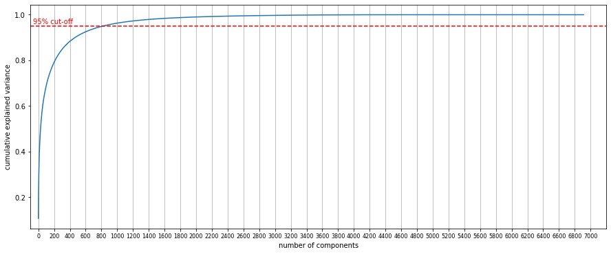

```python
plt.figure(figsize=(15,6))
plt.plot(range(1, len(v_ratio)+1), np.cumsum(v_ratio))
plt.axhline(y=0.95, color='r', linestyle='--')
plt.text(-70, 0.96, '95% cut-off', color = 'red', fontsize=10)
plt.grid(axis = 'x', visible = True)
plt.xticks(np.arange(0,7200, step = 200), size = 8)
plt.xlim([-100, 7200])
plt.xlabel('number of components')
plt.ylabel('cumulative explained variance');
```

From the graph we see that the best number of components will be 800.

```python
data_pca = pd.DataFrame(PCA(n_components= 800).fit_transform(data_for_pca))
data_pca.head()
```

|  | 0 | 1 | 2 | 3 | 4 | 5 | 6 | 7 | 8 | 9 | ... | 790 | 791 | 792 | 793 | 794 | 795 | 796 | 797 | 798 | 799 |
| --- | --- | --- | --- | --- | --- | --- | --- | --- | --- | --- | --- | --- | --- | --- | --- | --- | --- | --- | --- | --- | --- |
| 0 | -0.174584 | 0.012795 | -0.003713 | -0.026960 | -0.093796 | -0.012423 | 0.075179 | 0.010040 | -0.015135 | -0.005508 | ... | -0.026889 | 0.002352 | -0.010465 | 0.006101 | -0.002442 | 0.033408 | -0.005074 | 0.022121 | 0.031438 | 0.010894 |
| 1 | -0.180809 | 0.028162 | -0.003507 | -0.038870 | -0.085192 | -0.007809 | 0.020225 | -0.031119 | -0.011814 | -0.001818 | ... | 0.001434 | -0.000840 | -0.001064 | 0.001964 | 0.002710 | 0.002778 | 0.004564 | 0.002635 | 0.001465 | -0.003036 |
| 2 | -0.188810 | 0.068990 | -0.003434 | -0.059602 | -0.075368 | -0.026539 | 0.024711 | -0.028346 | -0.013572 | -0.002996 | ... | 0.000591 | 0.001358 | -0.000435 | -0.003213 | -0.002951 | 0.000100 | 0.006220 | 0.001231 | -0.004561 | -0.001150 |
| 3 | -0.180809 | 0.028162 | -0.003507 | -0.038870 | -0.085192 | -0.007809 | 0.020225 | -0.031119 | -0.011814 | -0.001818 | ... | 0.001434 | -0.000840 | -0.001064 | 0.001964 | 0.002710 | 0.002778 | 0.004564 | 0.002635 | 0.001465 | -0.003036 |
| 4 | -0.170354 | 0.024138 | -0.003445 | -0.051160 | -0.076226 | -0.008673 | 0.022579 | -0.030781 | -0.012716 | -0.001850 | ... | 0.009431 | 0.000140 | -0.011389 | -0.003850 | -0.021886 | 0.007910 | 0.012720 | -0.000485 | 0.000452 | -0.010907 |

5 rows × 800 columns

```python
 data_pca2=PCA(n_components=2).fit_transform(data_pca)
```

## Clustering

Once the dimensions have been reduced with PCA we can start modelling.

Models that we consider as worth testing:

- KMeans
- Agglomerative Clustering
- Birch

```python
from sklearn.manifold import TSNE
from sklearn.metrics import davies_bouldin_score

def scatter(x, colors):
    palette = np.array(sns.color_palette("hls", 10))

    f = plt.figure(figsize=(16,16))
    ax = plt.subplot(aspect='equal')
    sc = ax.scatter(x[:,0], x[:,1], lw=0, s=40,
                    c=palette[colors.astype(np.int)])
    ax.axis('off')
    txts = []
    for i in range(10):
        # Position of each label.
        xtext, ytext = np.median(x[colors == i, :], axis=0)
        txt = ax.text(xtext, ytext, str(i), fontsize=24)
        txts.append(txt)

    return f, ax, sc, txts


def modeling(model,df):
    df2 = df
    try:
        model.fit(df2)
        label = model.predict(df2)
    except:
        label = model.fit_predict(df2)


    plt.figure(figsize=(10,10))
    plt.scatter(x=df2[:,0], y=df2[:,1],label=label, c = label, cmap='viridis' )
    plt.show()

    label2 = model.fit_predict(df)
    print("davies_bouldin_score: " + str(davies_bouldin_score(df, label2)))


def modeling2(model,df):
    df2 = df
    try:
        model.fit(df2)
        label = model.predict(df2)
    except:
        label = model.fit_predict(df2)


    plt.figure(figsize=(10,10))
    plt.scatter(x=df2[:,0], y=df2[:,1],label=label, c = label, cmap='viridis')
    plt.show()
```

Firstly, we will see how the models perform without defining the number of clusters.

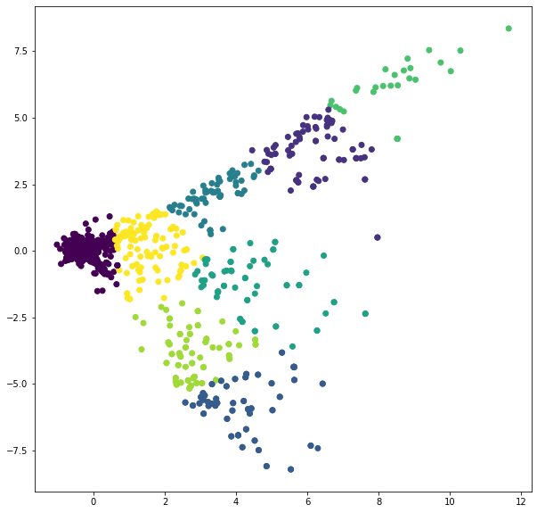

```
davies_bouldin_score: 0.7544605642946138
```

```python
from sklearn.cluster import KMeans

modeling(KMeans(random_state=0),data_pca2)
```

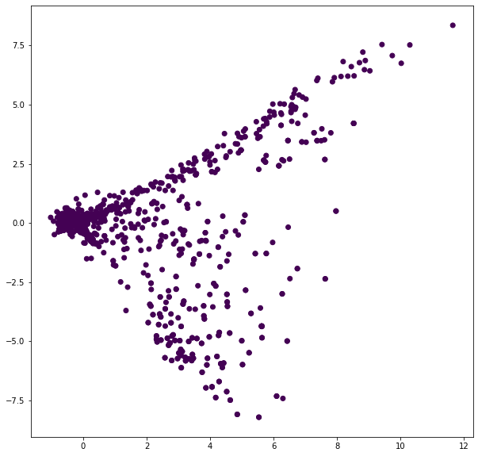

```python
from sklearn.cluster import Birch

modeling2(Birch(threshold=5), data_pca2)
```

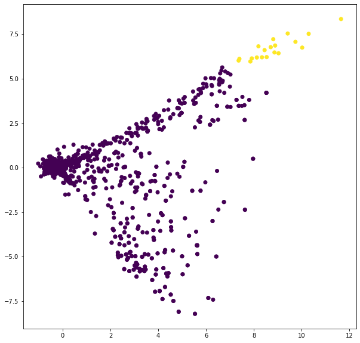

```
davies_bouldin_score: 0.12263036107615287
```

```python
from sklearn.cluster import AgglomerativeClustering

modeling(AgglomerativeClustering(linkage='complete'),data_pca2)
```

#### Short summary of the early clustering

None of them achieved satisfactory results, so for each of them we will try to determine the number of clusters. We will try techniques listed below:

- Elbow Method
- Silhouette Coefficient
- Calinski-Harabasz Index

```python
from yellowbrick.cluster import KElbowVisualizer
from sklearn.metrics import silhouette_score, davies_bouldin_score, calinski_harabasz_score
```

```python
def elbow(model,k_max):
    visualizer = KElbowVisualizer(model, k=(2,k_max), timings= False)
    visualizer.fit(data_pca2)
    visualizer.show()
```

```python
def silhouette(model, k_max):
    visualizer = KElbowVisualizer(model, k=(2,k_max),metric='silhouette', timings= False)
    visualizer.fit(data_pca2)
    visualizer.show()
```

```python
def calinski_harabasz(model, k_max):
    visualizer = KElbowVisualizer(model, k=(2,k_max),metric='calinski_harabasz', timings= False)
    visualizer.fit(data_pca2)
    visualizer.show()
```

### KMeans

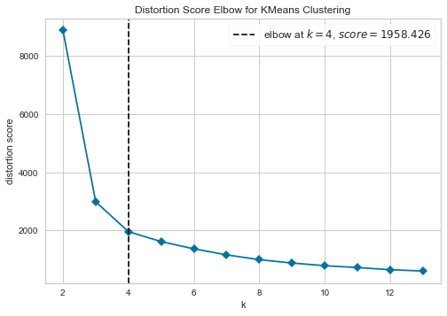

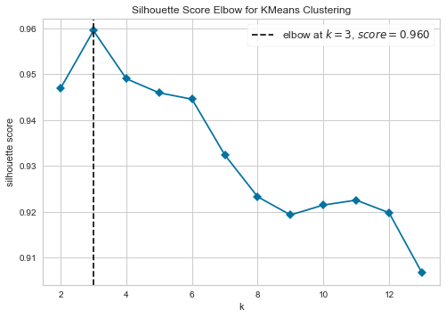

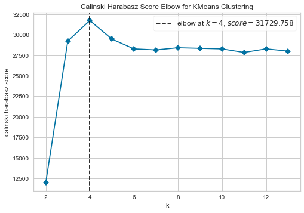

```python
elbow(KMeans(random_state= 0), 14)
silhouette(KMeans(random_state= 0), 14)
calinski_harabasz(KMeans(random_state= 0), 14)
```

### AgglomerativeClustering

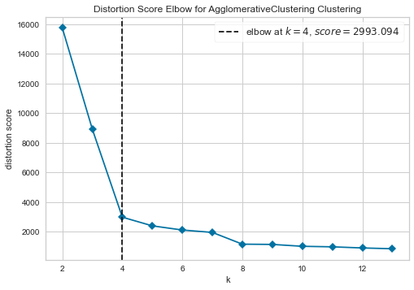

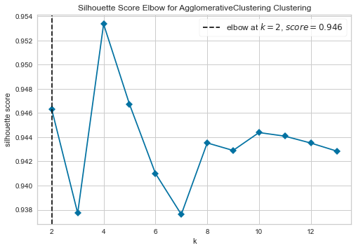

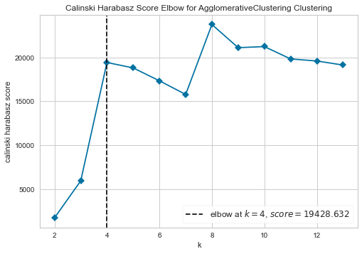

```python
elbow(AgglomerativeClustering(linkage='complete'), 14)
silhouette(AgglomerativeClustering(linkage='complete'), 14)
calinski_harabasz(AgglomerativeClustering(linkage='complete'), 14)
```

For this model we will also check Dendogram

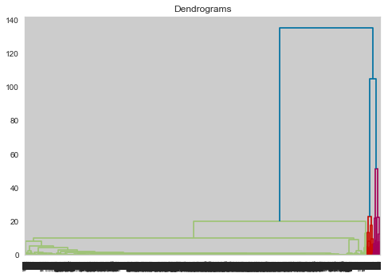

```python
import scipy.cluster.hierarchy as shc

plt.title("Dendrograms")
dend = shc.dendrogram(shc.linkage(data_pca2, method='ward'))
```

The dendogram shows 3 distinctive groups

### Birch

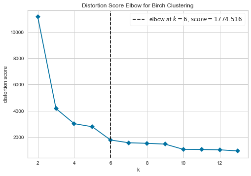

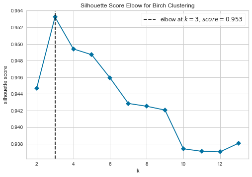

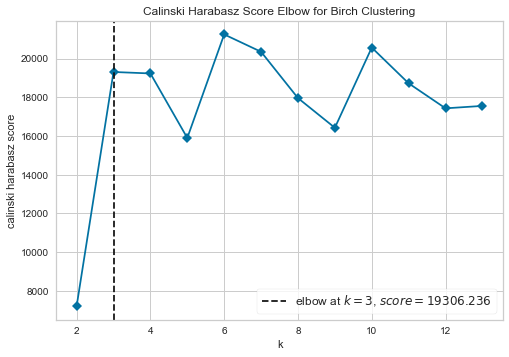

```python
elbow(Birch(), 14)
silhouette(Birch(), 14)
calinski_harabasz(Birch(), 14)
```

### Verification of clustering results for the optimal number of clusters selected above

#### KMeans

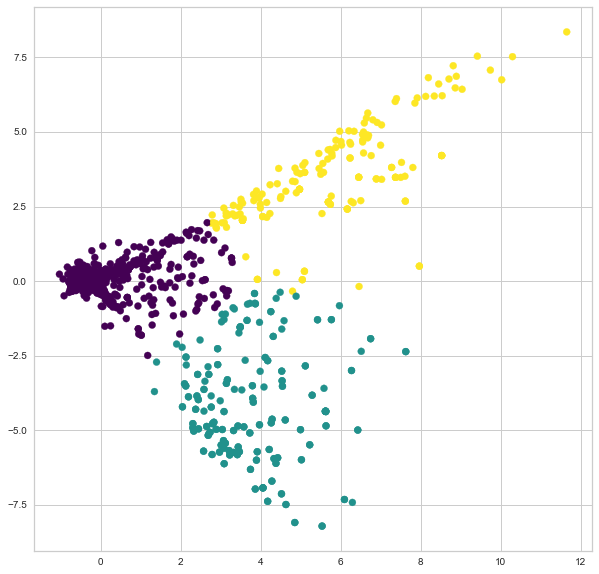

```
davies_bouldin_score: 0.4658052167407705
```

```python
from sklearn.cluster import KMeans
modeling(KMeans(n_clusters=3),data_pca2)
```

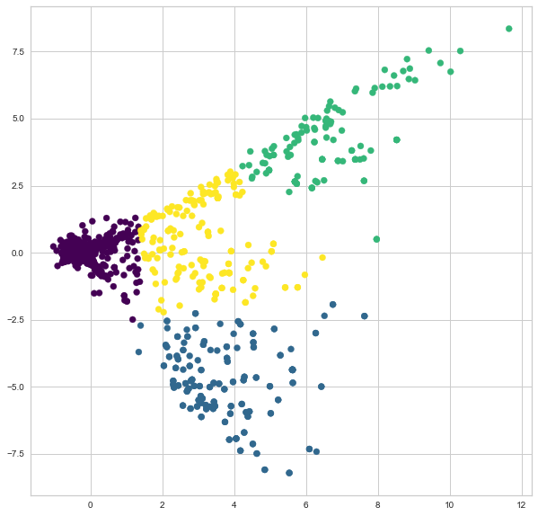

```
davies_bouldin_score: 0.6101818837430613
```

```python
modeling(KMeans(n_clusters=4),data_pca2)
```

#### AgglomerativeClustering

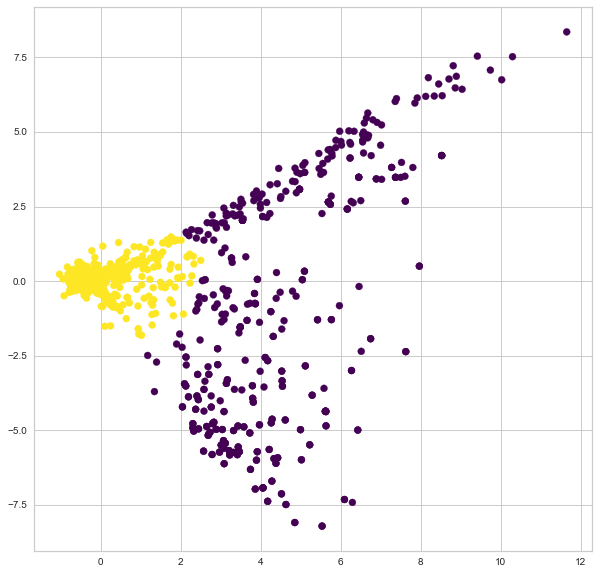

```
davies_bouldin_score: 0.8659567651887694
```

```python
modeling(AgglomerativeClustering(n_clusters=2),data_pca2)
```

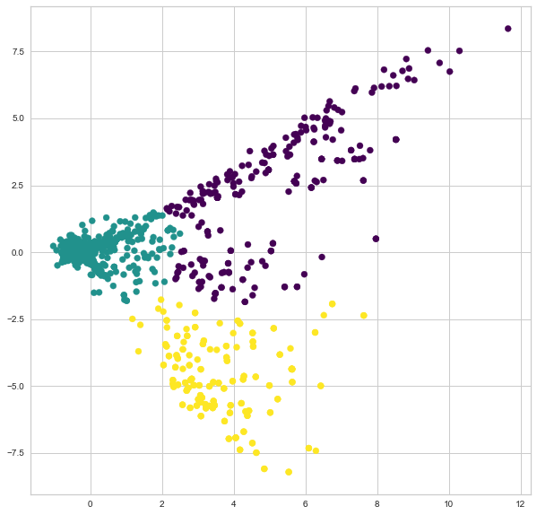

```
davies_bouldin_score: 0.5674707140139204
```

```python
modeling(AgglomerativeClustering(n_clusters=3),data_pca2)
```

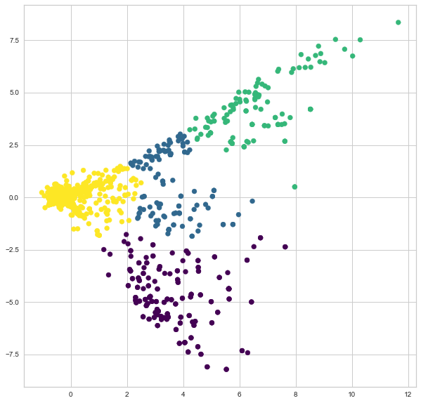

```
davies_bouldin_score: 0.6219774740062616
```

```python
modeling(AgglomerativeClustering(n_clusters=4),data_pca2)
```

#### Birch

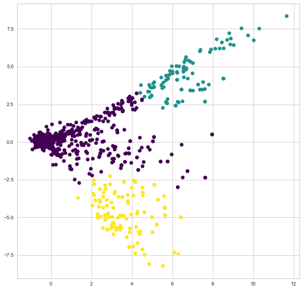

```
davies_bouldin_score: 0.3112163749484622
```

```python
modeling(Birch(n_clusters=3), data_pca2)
```

## Best model interpretability

```python
words = data_for_pca.idxmax(axis = 1)

model = Birch(n_clusters=3)
clusters = model.fit(data_pca).labels_.tolist()

df = pd.DataFrame(dict(x=data_pca2[:,0], y=data_pca2[:,1], label=clusters, word=words))
groups = df.groupby('label')
```

```python
words = data_for_pca.drop(columns = ['compani']).idxmax(axis = 1)

model = Birch(n_clusters=3)
clusters = model.fit(data_pca).labels_.tolist()

df = pd.DataFrame(dict(x=data_pca2[:,0], y=data_pca2[:,1], label=clusters, word=words))
groups = df.groupby('label')
```

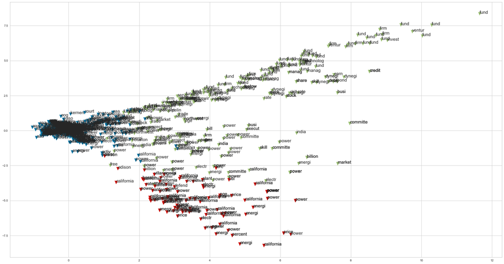

```python
fig, ax = plt.subplots(figsize=(30, 16))
cluster_names = {1: '1',
                 2: '2',
                 3: '3'}
for name, group in groups:
    ax.plot(group.x, group.y, ms=11, linestyle='', marker='v',
            label=clusters, mec='none')
for i in range(len(df)):
    ax.text(df.iloc[i,0], df.iloc[i,1], df.iloc[i,3], size=15)
plt.show()
```

```python
pd.DataFrame(df.loc[df['label'] == 0].word.value_counts()).head(10)
```

|  | word |
| --- | --- |
| aaa | 6984 |
| network | 121 |
| model | 98 |
| page | 80 |
| learn | 80 |
| california | 60 |
| power | 58 |
| updat | 58 |
| texa | 52 |
| price | 47 |

```python
pd.DataFrame(df.loc[df['label'] == 1].word.value_counts()).head(10)
```

|  | word |
| --- | --- |
| fund | 54 |
| power | 43 |
| firm | 26 |
| energi | 13 |
| manag | 13 |
| dynegi | 11 |
| skill | 11 |
| stock | 8 |
| committe | 7 |
| market | 6 |

```python
pd.DataFrame(df.loc[df['label'] == 2].word.value_counts()).head(10)
```

|  | word |
| --- | --- |
| california | 57 |
| power | 49 |
| energi | 22 |
| price | 8 |
| electr | 4 |
| rate | 4 |
| davi | 3 |
| edison | 3 |
| plant | 2 |
| ferc | 2 |